# HW2_B87772

EX1: The possible order of growth is:

$2^{2^{(n+1)}}$ , $2^{2^n}$ , $(n + 1)!$ , $n!$ , $e^n$ , $2^n$ , $2^{lg^*n}$ , $n^3$ , $n^2$ ,$nlg(n)$,$n$,$lg(n!)$, $ln(n)$,$lg^*n$, 1

for example:

$2^{(2^{(n+1)})}$ = $\Omega(2^{2^n})$

0 <= c * $2^{(2^{(n+1)})}$ <= $2^{2^n}$

c<= $2^{2^n}$/$2^{(2^{(n+1)})}$

c<= $1/2^{2^n}$

It means that for all c<=1/4,$2^{2^n}$ is a lower bound of $2^{(2^{(n+1)})}$

or:

$n^3$ = $\Omega (n^2)$

0 <= c * $n^3$ <= $n^2$

c <= $n^2$/ $n^3$

c <= 1/n

for all c<=1, $n^2$ is a lower bound of $n^3$

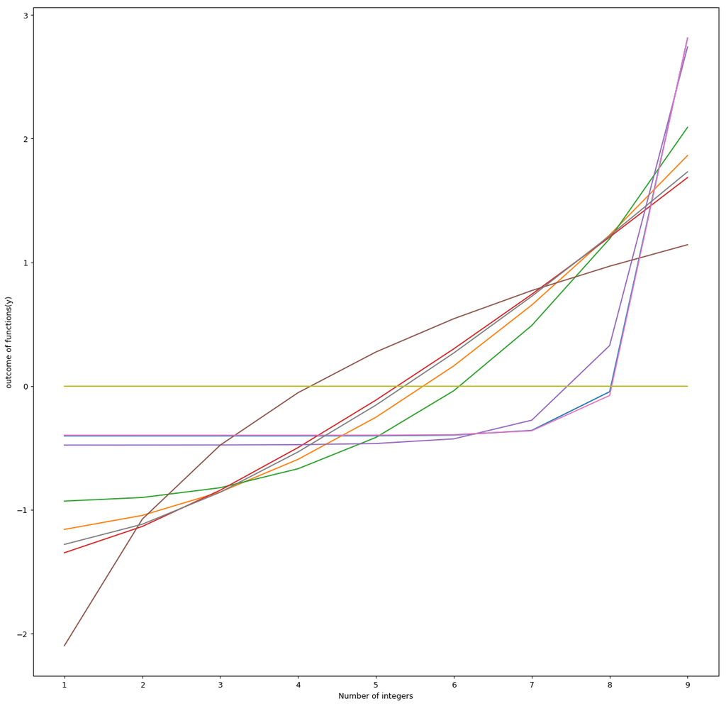

```python
import warnings
warnings.filterwarnings('ignore')

import numpy as np
import math as m
import matplotlib.pyplot as plt
from scipy.special import factorial
from matplotlib.pyplot import figure

from sklearn import preprocessing
def get_funcs(a):
    n = a

    n1 = factorial(n)
    n2 = np.power(n,2)
    n3 = np.power(n,3)
    n4 = n*np.log(n)
    n5 = np.power(2, np.multiply(2, n))
    n6 = np.log(n)
    n7 = factorial(np.add(n,1))
    n8 = np.log(factorial(n))
    n9 = np.power(n,0) #1
    n_list = [n1, n2, n3, n4, n5, n6, n7, n8, n9]
    return n_list

def scale_n(n):
    scaled_list = []

    for i in range(9):
        scaled_list.append(preprocessing.scale(n[i]))

    return scaled_list

n_list = get_funcs(range(1, 10))
n_list_scaled = scale_n(n_list)

figure(num=None, figsize=(16, 16), dpi=90)
plt.xlabel('Number of integers')
plt.ylabel('outcome of functions(y)')

for i in range(9):
    color = 'C' + str(i)

    plt.plot(range(1,10), n_list_scaled[i], color)

plt.show()
```

By decreasing the amount of integers we can flatten out on the plot.

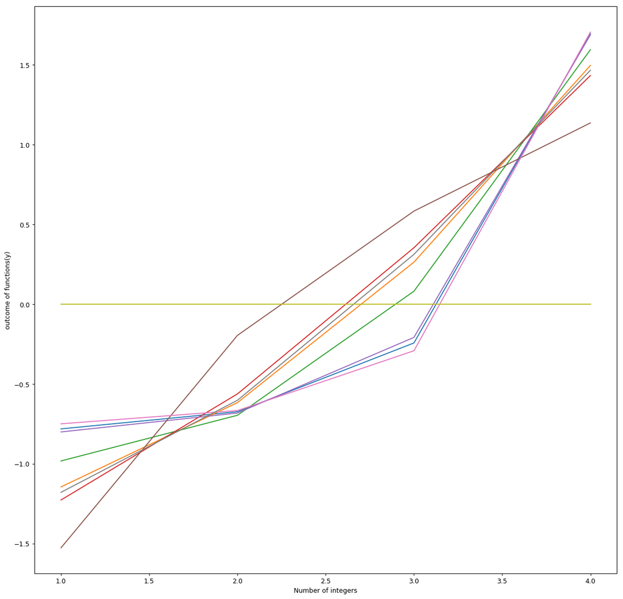

```python
n_list = get_funcs(range(1, 5))
n_list_scaled = scale_n(n_list)

figure(num=None, figsize=(16, 16), dpi=90)
plt.xlabel('Number of integers')
plt.ylabel('outcome of functions(y)')

for i in range(9):
    color = 'C' + str(i)

    plt.plot(range(1,5), n_list_scaled[i], color)

plt.show()
```

After some point they become the same as I predicted in the order of ex1

EX3:"For every problem whose solution can be quickly verified, one can also solve it quickly. E.g. if we can verify solution of a sudoku puzzle in O(n) where n is number of cells in the sudoku table, then we can come up with an algorithm of same order or polynomial degree to solve the puzzle" As Sudoku can be verified very quickly(in polynomial time), but the solution of it in the worst case can be O(n^2) it is known to be NP-complete. It also belongs to both NP-hard and NP complexity classes.

EX4: In the previous week I used a merge sort algorithm to sort the randomly generated array of items. As I supposed, the sorting of an array will take more time if the items of an array are in inverse order. However as I checked over and over again the inverse ordered array was faster than randomly generated array. I made an investigation and found that this process happens because of branch predictor. For inverse array in merge sort it predicts the same branch for each iteration and as the array is sorted it takes less time for computer to sort the inverse array. On the other hand if we send to a merge function an ascended sorted array it will take the least time for a merge sort function to sort it.

```python
import random, sys, time, numpy, math
import matplotlib.pyplot as plott

def mergeSort(mlist):
    if len(mlist)>1:
        mid = len(mlist)//2
        lefthalf = mlist[:mid]
        righthalf = mlist[mid:]

        mergeSort(lefthalf)
        mergeSort(righthalf)
        return merge(lefthalf, righthalf, mlist)

def merge(lefthalf, righthalf, mlist):
        i=0
        j=0
        k=0
        while i < len(lefthalf) and j < len(righthalf):
            if lefthalf[i] < righthalf[j]:
                mlist[k]=lefthalf[i]
                i=i+1
            else:
                mlist[k]=righthalf[j]
                j=j+1
            k=k+1

        while i < len(lefthalf):
            mlist[k]=lefthalf[i]
            i=i+1
            k=k+1

        while j < len(righthalf):
            mlist[k]=righthalf[j]
            j=j+1
            k=k+1

        return mlist
```

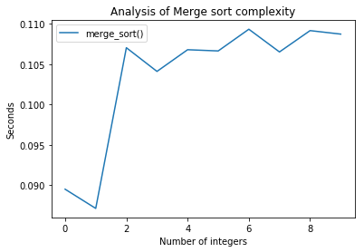

```
[0.08951663970947266, 0.08714056015014648, 0.10703349113464355, 0.10409998893737793, 0.10678434371948242, 0.10663437843322754, 0.10932111740112305, 0.10650968551635742, 0.10915040969848633, 0.10871744155883789]
```

```python
def increase():
    measures = []
    f_x = []
    checking_random_arr = numpy.array(numpy.random.randint(0,100000,10000, dtype=numpy.int64)).tolist()

    def measure_time(arr):
        startTime = time.time()
        mergeSort(arr.copy())
        duration = time.time() - startTime

        return duration

    for i in range(10):
        if i == 0:
            checking_random_arr_1 = sorted(checking_random_arr, reverse=True)
            duration = measure_time(checking_random_arr_1)
            measures.append(duration)
            continue
        if i == 1:
            checking_random_arr_2 = sorted(checking_random_arr)
            duration = measure_time(checking_random_arr_2)
            measures.append(duration)
            continue

        duration = measure_time(checking_random_arr)
        measures.append(duration)

    plott.title("Analysis of Merge sort complexity")
    plott.ylabel('Seconds')
    plott.xlabel('Number of integers')

    plott.plot(measures, label='merge_sort()')
    plott.legend()
    plott.show()

    print(measures)

increase()
```

In the code below I tried to figure out in which case merge sort works faster: 1) when it deals with ascending sorted array or 2) when it deals with reverse sorted array The outcome of this experiment varies and in most cases the results are similar, however the first case becomes faster more often.

```python
ascending = 0
reverse = 0
for i in range(50):
    x = numpy.array(numpy.random.randint(0,100000,10000, dtype=numpy.int64)).tolist()

    x = sorted(x)
    startTime = time.time()
    mergeSort(x.copy())
    duration1 = time.time() - startTime

    y = sorted(x, reverse=True)

    startTime = time.time()
    mergeSort(y.copy())
    duration2 = time.time() - startTime

    if(duration1 < duration2):
        ascending = ascending + 1
    if(duration1 > duration2):
        reverse = reverse + 1

print("the quantity of cases when ascending order becoming faster: " + str(ascending))
print("the quantity of cases when reversed order becoming faster: " + str(reverse))
```

```
the quantity of cases when ascending order becoming faster: 34
the quantity of cases when reversed order becoming faster: 16
```

EX5: In exercise 5 we have been provided with the statement that “The running time of algorithm A is at least O(n^2)” which is meaningless.

O-notation is an upper bound of a given function. However, the statement says that “The running time of algorithm A is at least O(n^2)” which implies that runtime of an algorithm can be larger than n^2. This statement becomes meaningless because it contradicts the definition of O-notation.